# Case Study: 16S microbiome data (Baxter et al., 2016)

## 5.10 Multiple-Testing Correction - Random

Let’s use `rand_covar` as our `ind_covariate`.

```r
res <- dplyr::mutate(res, ind_covariate = rand_covar)
```

First, we’ll create an object of `BenchDesign` class to hold the data and add the benchmark methods to the `BenchDesign` object. We remove ASH from the comparison.

Then, we’ll construct the `SummarizedBenchmark` object, which will run the functions specified in each method (these are actually sourced in from the helper scripts).

```r
if (!file.exists(gns_bench_file_uninf)) {
    bd <- initializeBenchDesign()
    bd <- dropBMethod(bd, "ashq")
    sb <- buildBench(bd, data = res, ftCols = "ind_covariate")
    metadata(sb)$data_download_link <-
                   "https://zenodo.org/record/840333/files/crc_baxter_results.tar.gz"
    saveRDS(sb, file = gns_bench_file_uninf)
} else {
    sb <- readRDS(gns_bench_file_uninf)
}
```

## 5.11 Benchmark Metrics - Random

Next, we’ll add the default performance metric for q-value assays. First, we have to rename the assay to ‘qvalue’.

```r
assayNames(sb) <- "qvalue"
sb <- addDefaultMetrics(sb)
```

Now, we’ll plot the results.

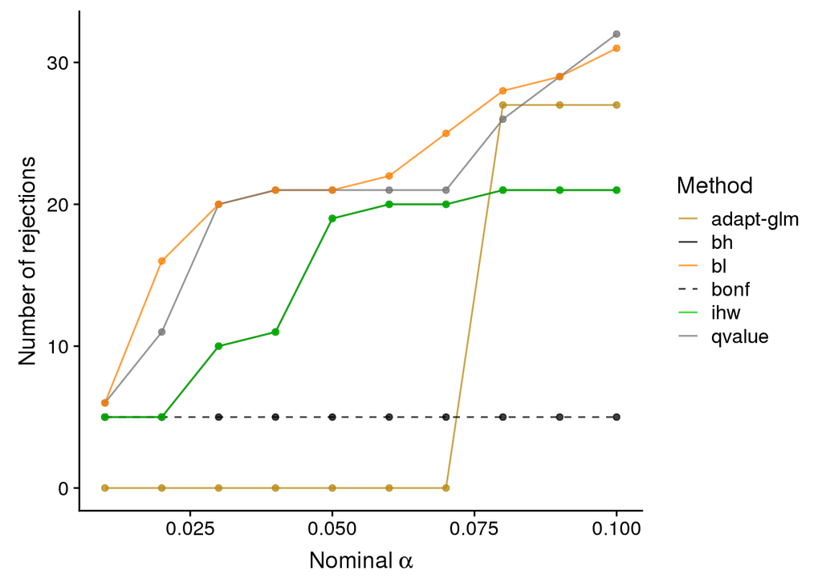

```r
rejections_scatter(sb, as_fraction=FALSE, supplementary=FALSE)
```

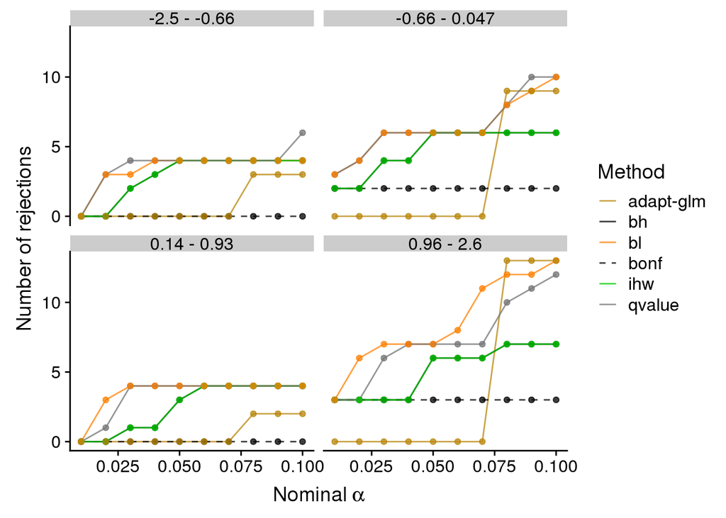

```r
rejection_scatter_bins(sb, covariate="ind_covariate", supplementary=FALSE)
```

Note: Benjamini-Hochberg (bh) overlaps exactly with the IHW results.

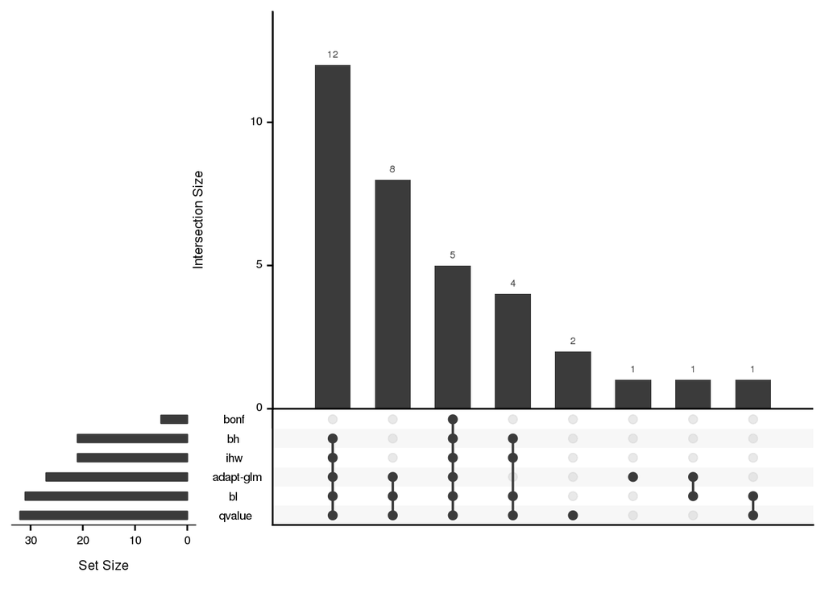

```r
plotFDRMethodsOverlap(sb, alpha=0.1, supplementary=FALSE, order.by="freq", nsets=100 )
```

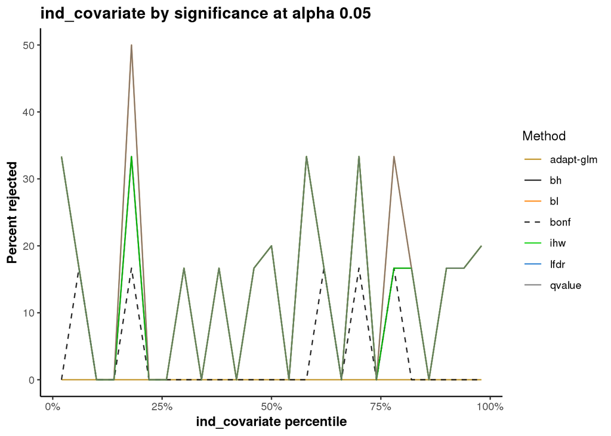

```r
covariateLinePlot(sb, alpha = 0.05, covname = "ind_covariate")
```

# 6 OTU/Genus comparison

Here we compare the method ranks for the different comparisons at alpha = 0.10.

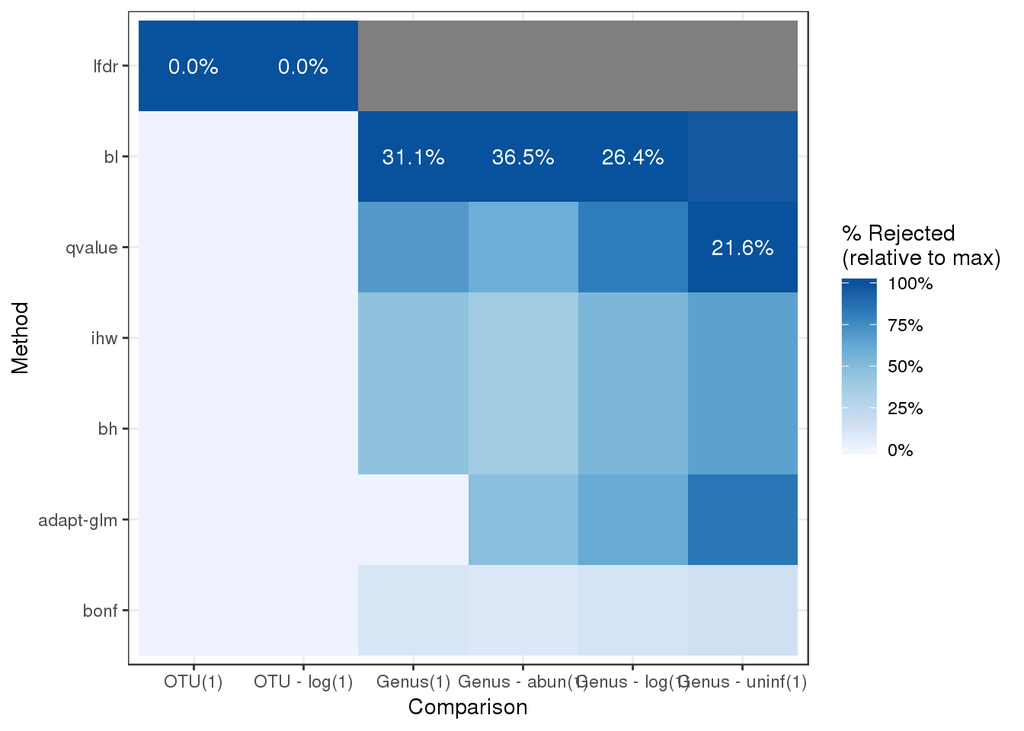

```r
plotMethodRanks(c(otu_bench_file, otu_bench_file_log_ubiquity,
                  gns_bench_file, gns_bench_file_log_ubiquity,
                  gns_bench_file_abun, gns_bench_file_uninf),
                colLabels = c("OTU", "OTU - log", "Genus", "Genus - log",
                              "Genus - abun", "Genus - uninf"),
                alpha = 0.10, xlab = "Comparison")
```